# Dokumentation der explorativen Faktorenanalysen

## „Neutral vermitteln“ oder „ermächtigend berichten“? Strukturelle Unterschiede von journalistischem Rollenselbstverständnis und bevölkerungsseitigen Erwartungen

Louise Sprengelmeyer / Julius Reimer / Hannah Immler / Wiebke Loosen / Julia Behre / Sascha Hölig

27. Juli 2022

Ergänzend zu unserem Aufsatz dokumentieren wir hier im Detail, wie wir bei den beiden **explorativen Faktorenanalysen** vorgegangen sind. In unserer Studie vergleichen wir journalistisches Rollenselbstverständnis und bevölkerungsseitige Erwartungen und zeigen strukturelle Unterschiede.

Für beide Gruppen, Journalist*innen und Bürger*innen in Deutschland, betrachten wir journalistische Rollenitems und -facetten explorativ. Dabei legen wir den Fokus auf latente Dimensionen, also Rollen, zu denen sich die Items bündeln lassen. Wir kommentieren die einzelnen Analyseschritte für die Gruppe der Journalist*innen, da wir diese zuerst betrachten. Danach stellen wir das faktorenanalytische Modell der Bevölkerung vor. Hier gestaltet sich unser Vorgehen identisch – die Bezeichnung der Faktoren mit von uns gefundenen Labeln ausgenommen. Bevölkerungsseitig zeigen wir daher direkt die Ergebnisse der einzelnen Schritte.

Grundsätzlich basiert unsere Analyse auf zwei Datensätzen, die unterschiedliche Gruppen von Befragten abbilden: zum einen Journalist*innen in Deutschland, zum anderen deutsche Bürger*innen. Die beiden repräsentativen Umfragen eint, dass beide Gruppen die Wichtigkeit von 21 identisch formulierten Rollenitems – übernommen aus der *Worlds of Journalism*-Studie (Hanitzsch et al. 2019) – auf einer 5-Punkte-Likert-Skala von “unwichtig” (“1”) bis “extrem wichtig” (“5”) bewerteten. Diese fünffach abgestuften Antwortkategorien erlauben uns, die empirisch ordinalskalierten Variablen in der statistischen Anwendung unter Vorbehalt als quasi-metrisch zu behandeln. Eine solche Interpretation ist möglich, da „die Abstände zwischen den Antworten semantisch und durch numerische Wertzuweisung als gleich groß interpretiert werden“ (Völkl & Korb 2018: 20) können. Die folgenden Rollenitems betrachten wir:

| Rollenitem | Abkürzung |
| --- | --- |
| Ein unparteiischer Beobachter sein | RoleA |
| Dinge so berichten, wie sie sind | RoleB |
| Aktuelles Geschehen einordnen und analysieren | RoleC |
| Die Regierung kontrollieren | RoleD |
| Die Wirtschaft kontrollieren | RoleE |
| Die politische Tagesordnung bestimmen | RoleF |
| Die öffentliche Meinung beeinflussen | RoleG |
| Für sozialen Wandel eintreten | RoleH |
| Ein Gegengewicht zur Regierung bilden | RoleJ |
| Nationale Entwicklung unterstützen | RoleK |
| Ein positives Bild der Regierung vermitteln | RoleL |
| Regierungspolitik unterstützen | RoleM |
| Unterhaltung und Entspannung bieten | RoleO |
| Inhalte anbieten, die ein möglichst großes Publikum anziehen | RoleP |
| Rat, Orientierung und Hilfestellung für den Alltag bieten | RoleR |
| Informationen vermitteln, die Menschen zu politischen Entscheidungen befähigen | RoleS |
| Menschen zur Teilhabe am politischen Geschehen motivieren | RoleT |
| Den Menschen die Möglichkeit geben, ihre Ansichten zu artikulieren | RoleU |
| Das Publikum bilden | RoleW |
| Als Erzähler die Welt in Geschichten vermitteln | RoleX |
| Toleranz und kulturelle Vielfalt fördern | RoleZ |

Eine Voraussetzung für faktorenanalytische Berechnungen ist, dass die Daten vollständig sind und dementsprechend keine Antwortausfälle vorkommen (Fricker et al. 2012). Der fusionierte Datensatz umfasst insgesamt 1.807 Fälle, Beobachtungen mit fehlenden Werten noch eingeschlossen: 775 Journalist*innen und 1032 Bürger*innen. Wir haben uns dazu entschieden, Fälle listenweise auszuschließen, sodass nur noch vollständige Beobachtungen vorliegen. Fehlende Werte haben wir in dieser Analyse folglich nicht über Imputationsverfahren vervollständigt. Denn auch nach Ausgrenzung betroffener Beobachtungen sind in beiden Gruppen – Journalist*innen wie Bürger*innen – noch 88 Prozent der Fälle vorhanden. Das finale Sample umfasst 689 Journalist*innen, bevölkerungsseitig sind noch 905 Fälle berücksichtigt. Derartige Stichprobengrößen eignen sich in Anlehnung an Bühner (2011) sowie Comrey und Lee (1992) sehr gut für faktorenanalytische Betrachtungen, da jeweils mehr als 500 Beobachtungen vorliegen.

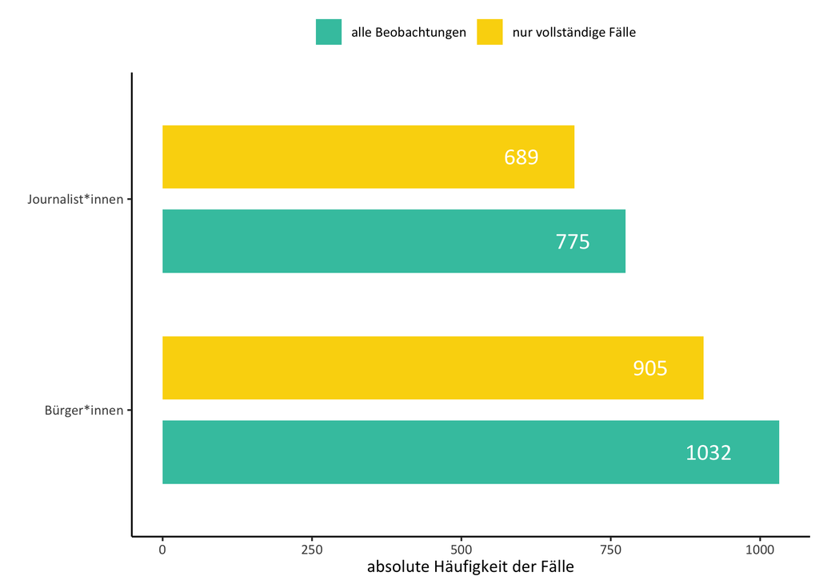

# Journalist*innen

```r
jou <- ri %>% filter(dataset == 2)
val_labels(jou) <- NULL
jou_na.omit <- na.omit(jou)
jou_cl <- jou_na.omit %>% select(3:23)
```

```r
jou_covwt <- cov.wt(jou_cl, wt = jou_na.omit$fusionweight, cor = T)
jou_cor <- jou_covwt$cor %>% round(2)
```

```r
corrplot01 <- ggcorrplot(jou_cor,
           type = "lower",
           lab = T,
           title = "Gewichtete Korrelationen der Indikatorvariablen im Datensatz der Journalist*innen",
           lab_size = 2.5,
           ggtheme = ggplot2::theme_minimal(base_family = "Calibri"),
           show.legend = T,
           legend.title = "",
           colors = c("#3ec4ae", "white", "#fad60c"))
ggsave("corrplot01.png", corrplot01, device = "png", width = 7, height = 7)
```

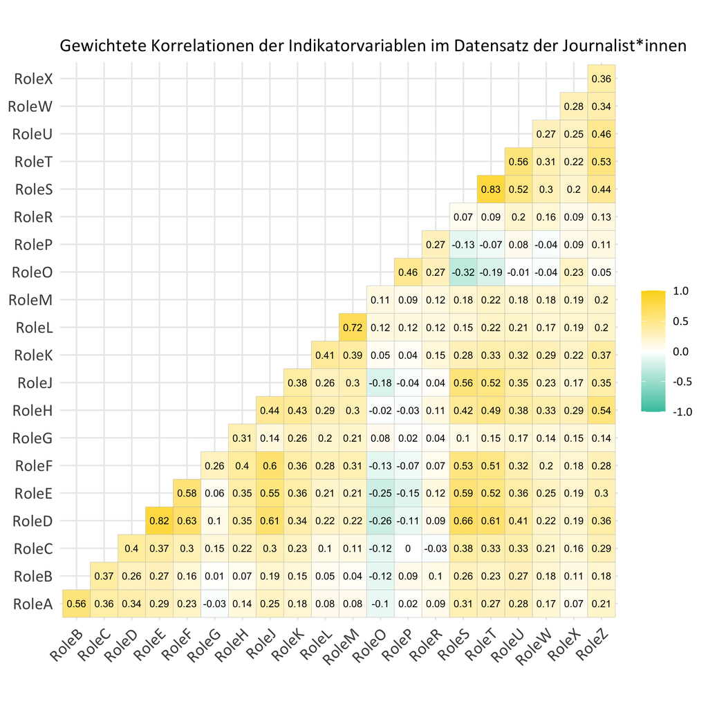

Um zu prüfen, inwiefern sich die Daten für eine Faktorenanalyse eignen, haben wir das Kaiser-Meyer-Olkin-Kriterium (KMO) herangezogen, denn dieser Signifikanztest setzt im Gegensatz zum ebenfalls häufig genutzten Bartlett-Test auf Sphärizität keine Normalverteilung voraus. Berechnen lässt sich ein Gesamtmaß und Maße für jede einzelne Variable. Insgesamt gilt: < 0,50 = keine EFA möglich; 0,50 - 0,59 = schlecht; 0,60 - 0,69 = mäßig; 0,70 - 0,79 = mittel, 0,80 - 0,90 = gut; > 0,90 = sehr gut (Klopp 2013: 4). Beim KMO-Test liegt der Gesamtwert aufseiten der Journalist*innen mit 0,86 im guten Bereich.

```r
kmo_jou <- KMO(jou_cor)
kmo_jou
```

```
Kaiser-Meyer-Olkin factor adequacy
Call: KMO(r = jou_cor)
Overall MSA =  0.86
MSA for each item =
RoleA RoleB RoleC RoleD RoleE RoleF RoleG RoleH RoleJ RoleK RoleL RoleM RoleO RoleP RoleR RoleS RoleT
 0.81  0.75  0.92  0.87  0.86  0.94  0.77  0.90  0.94  0.94  0.74  0.75  0.68  0.64  0.70  0.87  0.86
RoleU RoleW RoleX RoleZ
 0.95  0.92  0.84  0.90
```

Ein Blick auf die Einzelwerte in aufsteigender Reihenfolge zeigt: Der geringste Einzelwert beträgt hier 0,64 und liegt somit über dem Minimum von 0,50 (Backhaus et al. 2018) bzw. 0,60 (Hartmann & Reinecke 2013). Aufseiten der Bevölkerung liegt der Gesamtwert bei 0,87 und der geringste Einzelwert beläuft sich auf 0,79.

```r
kmo_jou$MSAi %>% sort()
```

```
    RoleP     RoleO     RoleR     RoleL     RoleB     RoleM     RoleG     RoleA     RoleX     RoleE
0.6413851 0.6819507 0.6996804 0.7434246 0.7521879 0.7544676 0.7714805 0.8053025 0.8376673 0.8591592
    RoleT     RoleS     RoleD     RoleZ     RoleH     RoleW     RoleC     RoleF     RoleK     RoleJ
0.8648029 0.8664493 0.8687842 0.8958100 0.9039742 0.9199914 0.9224060 0.9369963 0.9416243 0.9437513
    RoleU
0.9527468
```

Darüber hinaus ist die Determinante der jeweiligen Korrelationsmatrix nahe null (Journalist*innen = 0,0001; Bürger*innen = 0,0048) und erfüllt gleichzeitig die Bedingung größer als 0,00001 zu sein (Field et al. 2012).

```r
det(jou_cor)
```

```
[1] 0.0001029792
```

Um sich der Anzahl der Faktoren zu nähern, haben wir verschiedene Verfahren herangezogen: Kaiser-Guttman-Kriterium, Scree-Test und Parallelanalyse. Letzteres Verfahren vergleicht die Eigenwerte des vorliegenden Datensatzes mit normalverteilten Zufallsdaten (Bühner 2011). Wenngleich die Parallelanalyse ein genaueres Verfahren als der Scree-Test ist und eine weniger subjektive Interpretation erlaubt (Henson & Roberts 2006), sind die Ergebnisse dennoch mit Vorsicht zu interpretieren, da in keinem Sample eine Normalverteilung besteht. Die Daten der Journalist*innen deuten beim Scree-Plot auf zwei Faktoren hin, die Parallelanalyse legt sechs Faktoren nahe. Der Scree-Plot für die Bevölkerungsdaten deutet auf drei und die Parallelanalyse auf fünf Faktoren hin.

```
Parallel analysis suggests that the number of factors =  6  and the number of components =  NA
```

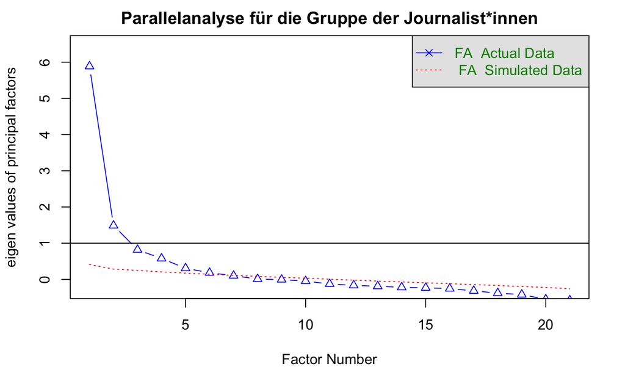

```r
fa.parallel(jou_cor, n.obs = nrow(jou_cl), fa = "fa", fm = "uls", main = "Parallelanalyse für die Gruppe der Journalist*innen")
```

Wir haben daher mehrere Variationen der Faktorenanzahl geprüft, die Lösungen variierten hierbei zwischen zwei und sechs Faktoren. Für die Journalist*innen haben wir final eine sechs-faktorielle Lösung gewählt, aufseiten der Bevölkerung eine vier-Faktoren-Lösung. Als Schätzverfahren wurde das Unweighted Least Squares (ULS)-Verfahren genutzt, weil bei dieser Methode keine Annahmen einer Normalverteilung nötig sind.

Die Achsen haben wir rotiert, um eine inhaltliche Interpretation der Faktoren zu erleichtern. Die Rotation der jeweiligen Lösung zielt auf eine Einfachstruktur ab: Eine Variable lädt im Idealfall auf einen Faktor möglichst hoch und auf die übrigen deutlich schwächer (Backhaus et al. 2018), Faktoren können somit deutlicher voneinander abgegrenzt werden. Wir haben uns für eine orthogonale, also rechtwinklige, Rotation entschieden, die Faktoren bleiben also unabhängig voneinander (Korrelation = 0).

Im Falle von Doppelladungen haben wir das Fürntratt-Kriterium (quadrierte Faktorladung geteilt durch die Kommunalität > 0,50) als Entscheidungshilfe bei der Zuordnung der Variablen herangezogen. Aufseiten der Journalist*innen weisen zwei Items Doppelladungen > 0,40 auf. Hier lädt das Rollenitem „Informationen vermitteln, die Menschen zu politischen Entscheidungen befähigen“ (RoleS) mit 0,50 auf einen Faktor (ULS1) sowie mit 0,69 auf einen weiteren Faktor (ULS5). Die Kommunalität liegt bei 0,84. Die quadrierte Korrelation des Items mit dem Faktor ULS5 beträgt 57% der Itemkommunalität. Das Item haben wir dementsprechend diesem Faktor zugewiesen (ULS1, 30%). Das Rollenitem „Menschen zur Teilhabe am politischen Geschehen motivieren“ (RoleT) lädt aufseiten der Journalist*innen ebenfalls auf ULS1 (0,41) und ULS5 (0,73) hoch. Die Kommunalität beträgt auch hier 0,84. Das Item haben wir daher dem Faktor ULS5 (63%) zugewiesen (ULS1, 20%).

**Informationen zu den Komponenten des Outputs**

Anbei gehen wir noch auf wichtige Komponenten des Outputs ein, übernommen von [Zezula und Brachem](https://pzezula.pages.gwdg.de/sheet_pca_fa.pdf).

[output not shown]

```r
jou_varimax = fa(jou_cor, n.obs = nrow(jou_cl), nfactor = 6, fm = "uls", rotate = "varimax")
```

```r
print(jou_varimax)
```

```
Factor Analysis using method =  uls
Call: fa(r = jou_cor, nfactors = 6, n.obs = nrow(jou_cl), rotate = "varimax",
    fm = "uls")
Standardized loadings (pattern matrix) based upon correlation matrix
       ULS1  ULS6  ULS3  ULS5 ULS4  ULS2   h2   u2 com
RoleA  0.18  0.05  0.66  0.11 0.03  0.03 0.48 0.52 1.2
RoleB  0.09  0.04  0.80  0.07 0.00  0.06 0.65 0.35 1.1
RoleC  0.27  0.24  0.42  0.12 0.01 -0.04 0.32 0.68 2.6
RoleD  0.85  0.15  0.22  0.23 0.07 -0.04 0.85 0.15 1.4
RoleE  0.79  0.17  0.22  0.15 0.07 -0.07 0.73 0.27 1.4
RoleF  0.64  0.27  0.09  0.14 0.20 -0.04 0.55 0.45 1.8
RoleG  0.08  0.37 -0.04 -0.03 0.16  0.02 0.17 0.83 1.5
RoleH  0.24  0.67  0.01  0.22 0.15 -0.02 0.58 0.42 1.6
RoleJ  0.58  0.29  0.13  0.22 0.18 -0.07 0.52 0.48 2.2
RoleK  0.27  0.47  0.13  0.04 0.32  0.08 0.41 0.59 2.7
RoleL  0.12  0.20  0.02  0.05 0.80  0.13 0.72 0.28 1.2
RoleM  0.14  0.21  0.01  0.05 0.79  0.10 0.71 0.29 1.3
RoleO -0.19  0.13 -0.15 -0.17 0.05  0.73 0.65 0.35 1.4
RoleP -0.11 -0.01  0.06  0.00 0.07  0.61 0.39 0.61 1.1
RoleR  0.07  0.08  0.07  0.07 0.06  0.41 0.19 0.81 1.3
RoleS  0.50  0.22  0.21  0.69 0.04 -0.14 0.84 0.16 2.4
RoleT  0.41  0.32  0.15  0.73 0.08 -0.04 0.84 0.16 2.2
RoleU  0.24  0.35  0.26  0.42 0.06  0.16 0.45 0.55 3.7
RoleW  0.10  0.42  0.18  0.15 0.07  0.01 0.24 0.76 1.9
RoleX  0.09  0.42  0.06  0.08 0.06  0.22 0.24 0.76 1.8
RoleZ  0.15  0.58  0.16  0.36 0.02  0.15 0.54 0.46 2.2

                      ULS1 ULS6 ULS3 ULS5 ULS4 ULS2
SS loadings           2.94 2.15 1.61 1.60 1.54 1.25
Proportion Var        0.14 0.10 0.08 0.08 0.07 0.06
Cumulative Var        0.14 0.24 0.32 0.40 0.47 0.53
Proportion Explained  0.27 0.19 0.15 0.14 0.14 0.11
Cumulative Proportion 0.27 0.46 0.60 0.75 0.89 1.00

Mean item complexity =  1.8
Test of the hypothesis that 6 factors are sufficient.

The degrees of freedom for the null model are  210  and the objective function was  9.18 with Chi Square of  6244.6
The degrees of freedom for the model are 99  and the objective function was  0.45

The root mean square of the residuals (RMSR) is  0.02
The df corrected root mean square of the residuals is  0.03

The harmonic number of observations is  689 with the empirical chi square  157.99  with prob <  0.00015
The total number of observations was  689  with Likelihood Chi Square =  304.26  with prob <  9.9e-23

Tucker Lewis Index of factoring reliability =  0.927
RMSEA index =  0.055  and the 90 % confidence intervals are  0.048 0.062
BIC =  -342.72
Fit based upon off diagonal values = 0.99
Measures of factor score adequacy
                                                  ULS1 ULS6 ULS3 ULS5 ULS4 ULS2
Correlation of (regression) scores with factors   0.91 0.82 0.86 0.87 0.89 0.83
Multiple R square of scores with factors          0.84 0.67 0.74 0.76 0.79 0.70
Minimum correlation of possible factor scores     0.67 0.34 0.47 0.51 0.58 0.39
```

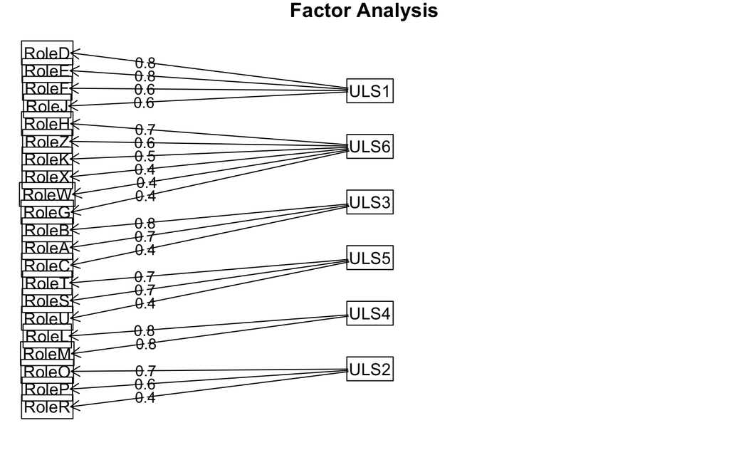

```r
fa.diagram(jou_varimax)
```

Die Tabelle ist sortiert nach den Eigenwerten, also der Summe der quadrierten Ladungen.

```r
jou_output <- fa.organize(jou_varimax$loadings,paste0("ULS", 1:6))
jou_output <- as.data.frame(jou_output)
jou_output <- jou_output %>%
  rownames_to_column(var = "Variable") %>%
  mutate(Faktor = colnames(jou_output)[apply(jou_output,1,which.max)]) %>%
  mutate(Faktorladung = apply(jou_output,1,max)) %>%
  select(Faktor, Faktorladung, Variable) %>%
  mutate(
    Anordnung = case_when(
      Faktor == "ULS1" ~ "1",
      Faktor == "ULS6" ~ "2",
      Faktor == "ULS3" ~ "3",
      Faktor == "ULS5" ~ "4",
      Faktor == "ULS4" ~ "5",
      Faktor == "ULS2" ~ "6",
      TRUE ~ "Kontrolle"
    )
  ) %>%
  mutate(
    Beschreibung = case_when(
      Faktor == "ULS1" ~ "Faktor 1",
      Faktor == "ULS6" ~ "Faktor 2",
      Faktor == "ULS3" ~ "Faktor 3",
      Faktor == "ULS5" ~ "Faktor 4",
      Faktor == "ULS4" ~ "Faktor 5",
      Faktor == "ULS2" ~ "Faktor 6",
      TRUE ~ "Kontrolle"
    )
  ) %>%
  arrange(Anordnung, desc(Faktorladung)) %>%
  mutate_if(is.numeric, ~round(., 2))
jou_viz <- full_join(jou_output, label, by = "Variable") %>% select(Beschreibung, Faktorladung, Label, Variable) %>% dplyr::rename("Rollenitem" = "Label")
kable(jou_viz, format = "html", escape = FALSE) %>%
  kable_styling(bootstrap_options = c("condensed", "responsive")) %>%
  collapse_rows(columns = 1, valign = "top")
```

| Beschreibung | Faktorladung | Rollenitem | Variable |
| --- | --- | --- | --- |
| Faktor 1 | 0.85 | Die Regierung kontrollieren | RoleD |
|  | 0.79 | Die Wirtschaft kontrollieren | RoleE |
|  | 0.64 | Die politische Tagesordnung bestimmen | RoleF |
|  | 0.58 | Ein Gegengewicht zur Regierung bilden | RoleJ |
| Faktor 2 | 0.67 | Für sozialen Wandel eintreten | RoleH |
|  | 0.58 | Toleranz und kulturelle Vielfalt fördern | RoleZ |
|  | 0.47 | Nationale Entwicklung unterstützen | RoleK |
|  | 0.42 | Als Erzähler die Welt in Geschichten vermitteln | RoleX |
|  | 0.42 | Das Publikum bilden | RoleW |
|  | 0.37 | Die öffentliche Meinung beeinflussen | RoleG |
| Faktor 3 | 0.80 | Dinge so berichten, wie sie sind | RoleB |
|  | 0.66 | Ein unparteiischer Beobachter sein | RoleA |
|  | 0.42 | Aktuelles Geschehen einordnen und analysieren | RoleC |
| Faktor 4 | 0.73 | Menschen zur Teilhabe am politischen Geschehen motivieren | RoleT |
|  | 0.69 | Informationen vermitteln, die Menschen zu politischen Entscheidungen befähigen | RoleS |
|  | 0.42 | Den Menschen die Möglichkeit geben, ihre Ansichten zu artikulieren | RoleU |
| Faktor 5 | 0.80 | Ein positives Bild der Regierung vermitteln | RoleL |
|  | 0.79 | Regierungspolitik unterstützen | RoleM |
| Faktor 6 | 0.73 | Unterhaltung und Entspannung bieten | RoleO |
|  | 0.61 | Inhalte anbieten, die ein möglichst großes Publikum anziehen | RoleP |
|  | 0.41 | Rat, Orientierung und Hilfestellung für den Alltag bieten | RoleR |

```r
write.csv2(jou_viz, "jou_tbl.csv")
```

# Bevölkerung

```r
aud <- ri %>% filter(dataset == 1)
val_labels(aud) <- NULL
aud_na.omit <- na.omit(aud)
aud_cl <- aud_na.omit %>% select(3:23)
```

```r
aud_covwt <- cov.wt(aud_cl, wt = aud_na.omit$fusionweight, cor = T)
```

```r
aud_cor <- aud_covwt$cor %>% round(2)
```

```r
corrplot02 <- ggcorrplot(aud_cor,
           type = "lower",
           lab = T,
           title = "Gewichtete Korrelationen der Indikatorvariablen im Bevölkerungs-Datensatz",
           lab_size = 2.5,
           ggtheme = ggplot2::theme_minimal(base_family = "Calibri"),
           show.legend = T,
           legend.title = "",
           colors = c("#3ec4ae", "white", "#fad60c"))
ggsave("corrplot02.png", corrplot02, device = "png", width = 7, height = 7)
```

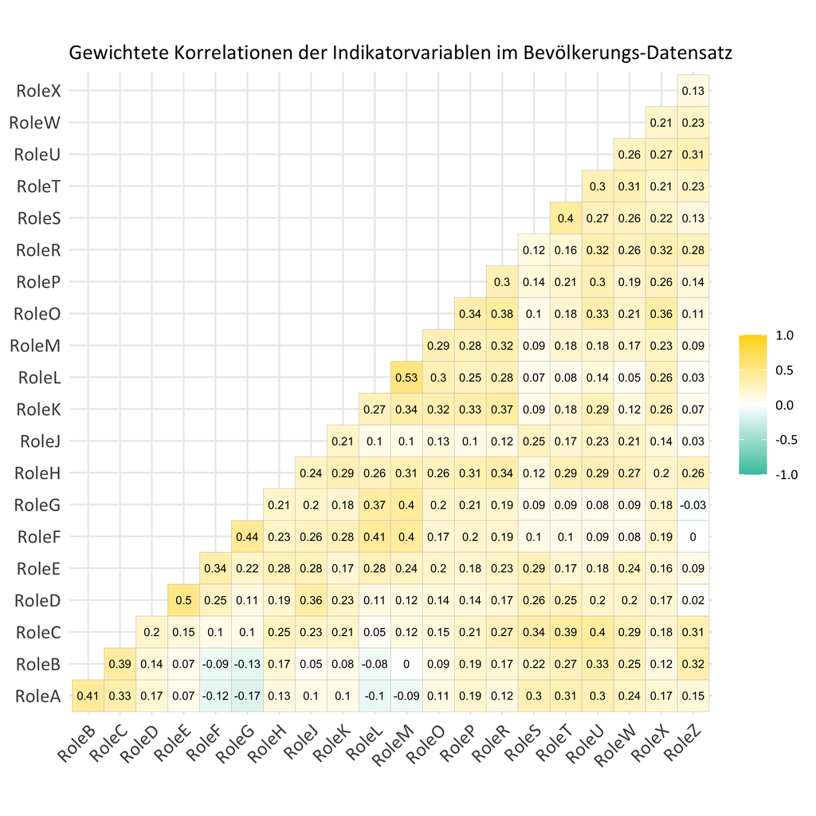

```r
kmo_aud <- KMO(aud_cor)
kmo_aud
```

```
Kaiser-Meyer-Olkin factor adequacy
Call: KMO(r = aud_cor)
Overall MSA =  0.87
MSA for each item =
RoleA RoleB RoleC RoleD RoleE RoleF RoleG RoleH RoleJ RoleK RoleL RoleM RoleO RoleP RoleR RoleS RoleT
 0.84  0.85  0.89  0.79  0.81  0.87  0.85  0.91  0.84  0.89  0.85  0.86  0.89  0.92  0.90  0.84  0.87
RoleU RoleW RoleX RoleZ
 0.92  0.91  0.91  0.82
```

```r
kmo_aud$MSAi %>% sort()
```

```
    RoleD     RoleE     RoleZ     RoleJ     RoleA     RoleS     RoleG     RoleB     RoleL     RoleM
0.7905140 0.8070590 0.8173692 0.8374200 0.8403397 0.8429139 0.8505298 0.8516098 0.8537547 0.8618013
    RoleF     RoleT     RoleK     RoleO     RoleC     RoleR     RoleH     RoleX     RoleW     RoleU
0.8707433 0.8727011 0.8863929 0.8923047 0.8924654 0.9000780 0.9118168 0.9118550 0.9127402 0.9189864
    RoleP
0.9224432
```

```r
det(aud_cor)
```

```
[1] 0.004808183
```

```
Parallel analysis suggests that the number of factors =  5  and the number of components =  NA
```

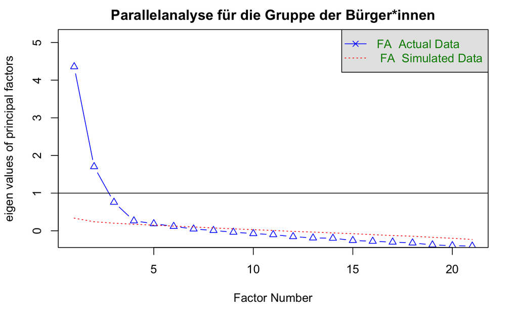

```r
fa.parallel(aud_cor, n.obs = nrow(aud_cl), fa = "fa", fm = "uls", main = "Parallelanalyse für die Gruppe der Bürger*innen")
```

```r
aud_varimax = fa(aud_cor, n.obs = nrow(aud_cl), nfactor = 4, fm = "uls", rotate = "varimax")
```

```r
print(aud_varimax)
```

```
Factor Analysis using method =  uls
Call: fa(r = aud_cor, nfactors = 4, n.obs = nrow(aud_cl), rotate = "varimax",
    fm = "uls")
Standardized loadings (pattern matrix) based upon correlation matrix
       ULS4 ULS1  ULS2  ULS3   h2   u2 com
RoleA  0.49 0.15 -0.31  0.15 0.39 0.61 2.1
RoleB  0.57 0.14 -0.21  0.02 0.39 0.61 1.4
RoleC  0.63 0.13  0.07  0.14 0.44 0.56 1.2
RoleD  0.12 0.15  0.01  0.73 0.57 0.43 1.1
RoleE  0.12 0.17  0.25  0.55 0.41 0.59 1.7
RoleF -0.04 0.17  0.58  0.31 0.46 0.54 1.7
RoleG -0.02 0.15  0.60  0.14 0.40 0.60 1.2
RoleH  0.31 0.35  0.26  0.14 0.30 0.70 3.2
RoleJ  0.17 0.08  0.15  0.45 0.26 0.74 1.6
RoleK  0.10 0.50  0.19  0.17 0.32 0.68 1.6
RoleL -0.05 0.37  0.56  0.08 0.46 0.54 1.8
RoleM  0.08 0.37  0.60  0.03 0.50 0.50 1.7
RoleO  0.11 0.60  0.13  0.08 0.40 0.60 1.2
RoleP  0.23 0.47  0.16  0.07 0.30 0.70 1.8
RoleR  0.24 0.55  0.18  0.05 0.40 0.60 1.6
RoleS  0.46 0.00  0.07  0.34 0.33 0.67 1.9
RoleT  0.55 0.10  0.10  0.20 0.36 0.64 1.4
RoleU  0.47 0.40  0.01  0.12 0.40 0.60 2.1
RoleW  0.42 0.18  0.06  0.19 0.25 0.75 1.8
RoleX  0.19 0.42  0.13  0.13 0.25 0.75 1.9
RoleZ  0.46 0.17  0.02 -0.10 0.25 0.75 1.4

                      ULS4 ULS1 ULS2 ULS3
SS loadings           2.43 2.11 1.81 1.51
Proportion Var        0.12 0.10 0.09 0.07
Cumulative Var        0.12 0.22 0.30 0.37
Proportion Explained  0.31 0.27 0.23 0.19
Cumulative Proportion 0.31 0.58 0.81 1.00

Mean item complexity =  1.7
Test of the hypothesis that 4 factors are sufficient.

The degrees of freedom for the null model are  210  and the objective function was  5.34 with Chi Square of  4783.23
The degrees of freedom for the model are 132  and the objective function was  0.45

The root mean square of the residuals (RMSR) is  0.03
The df corrected root mean square of the residuals is  0.04

The harmonic number of observations is  905 with the empirical chi square  343.37  with prob <  9.6e-21
The total number of observations was  905  with Likelihood Chi Square =  406.5  with prob <  1e-29

Tucker Lewis Index of factoring reliability =  0.904
RMSEA index =  0.048  and the 90 % confidence intervals are  0.043 0.053
BIC =  -492.15
Fit based upon off diagonal values = 0.98
Measures of factor score adequacy
                                                  ULS4 ULS1 ULS2 ULS3
Correlation of (regression) scores with factors   0.85 0.80 0.82 0.82
Multiple R square of scores with factors          0.72 0.64 0.68 0.67
Minimum correlation of possible factor scores     0.45 0.28 0.36 0.35
```

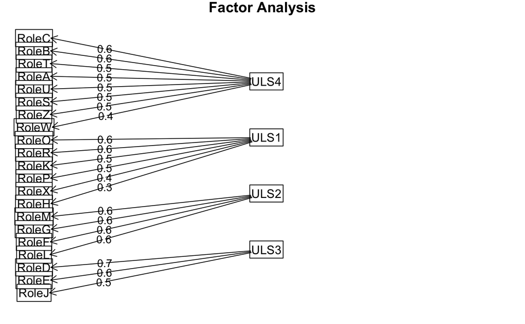

```r
fa.diagram(aud_varimax)
```

```r
aud_output <- fa.organize(aud_varimax$loadings,paste0("ULS", 1:4))
aud_output <- as.data.frame(aud_output)
aud_output <- aud_output %>%
  rownames_to_column(var = "Variable") %>%
  mutate(Faktor = colnames(aud_output)[apply(aud_output,1,which.max)]) %>%
  mutate(Faktorladung = apply(aud_output,1,max)) %>%
  select(Faktor, Faktorladung, Variable) %>%
  mutate(
    Anordnung = case_when(
      Faktor == "ULS4" ~ "1",
      Faktor == "ULS1" ~ "2",
      Faktor == "ULS2" ~ "3",
      Faktor == "ULS3" ~ "4",
      TRUE ~ "Kontrolle"
    )
  ) %>%
  mutate(
    Beschreibung = case_when(
      Faktor == "ULS4" ~ "Ermächtigendes Berichten und Einordnen",
      Faktor == "ULS1" ~ "Orientierende Unterhaltung und Hilfestellung",
      Faktor == "ULS2" ~ "Regierungsunterstützendes Agenda Setting",
      Faktor == "ULS3" ~ "Kontrolle Mächtiger",
      TRUE ~ "Kontrolle"
    )
  ) %>%
  arrange(Anordnung, desc(Faktorladung)) %>%
  mutate_if(is.numeric, ~round(., 2))
aud_viz <- full_join(aud_output, label, by = "Variable") %>% select(Beschreibung, Faktor, Faktorladung, Label, Variable) %>% dplyr::rename("Rollenitem" = "Label")
kable(aud_viz, format = "html", escape = FALSE) %>%
  kable_styling(bootstrap_options = c("condensed", "responsive")) %>%
  collapse_rows(columns = 1, valign = "top")
```

| Beschreibung | Faktor | Faktorladung | Rollenitem | Variable |
| --- | --- | --- | --- | --- |
| Ermächtigendes Berichten und Einordnen | ULS4 | 0.63 | Aktuelles Geschehen einordnen und analysieren | RoleC |
|  | ULS4 | 0.57 | Dinge so berichten, wie sie sind | RoleB |
|  | ULS4 | 0.55 | Menschen zur Teilhabe am politischen Geschehen motivieren | RoleT |
|  | ULS4 | 0.49 | Ein unparteiischer Beobachter sein | RoleA |
|  | ULS4 | 0.47 | Den Menschen die Möglichkeit geben, ihre Ansichten zu artikulieren | RoleU |
|  | ULS4 | 0.46 | Informationen vermitteln, die Menschen zu politischen Entscheidungen befähigen | RoleS |
|  | ULS4 | 0.46 | Toleranz und kulturelle Vielfalt fördern | RoleZ |
|  | ULS4 | 0.42 | Das Publikum bilden | RoleW |
| Orientierende Unterhaltung und Hilfestellung | ULS1 | 0.60 | Unterhaltung und Entspannung bieten | RoleO |
|  | ULS1 | 0.55 | Rat, Orientierung und Hilfestellung für den Alltag bieten | RoleR |
|  | ULS1 | 0.50 | Nationale Entwicklung unterstützen | RoleK |
|  | ULS1 | 0.47 | Inhalte anbieten, die ein möglichst großes Publikum anziehen | RoleP |
|  | ULS1 | 0.42 | Als Erzähler die Welt in Geschichten vermitteln | RoleX |
|  | ULS1 | 0.35 | Für sozialen Wandel eintreten | RoleH |
| Regierungsunterstützendes Agenda Setting | ULS2 | 0.60 | Regierungspolitik unterstützen | RoleM |
|  | ULS2 | 0.60 | Die öffentliche Meinung beeinflussen | RoleG |
|  | ULS2 | 0.58 | Die politische Tagesordnung bestimmen | RoleF |
|  | ULS2 | 0.56 | Ein positives Bild der Regierung vermitteln | RoleL |
| Kontrolle Mächtiger | ULS3 | 0.73 | Die Regierung kontrollieren | RoleD |
|  | ULS3 | 0.55 | Die Wirtschaft kontrollieren | RoleE |
|  | ULS3 | 0.45 | Ein Gegengewicht zur Regierung bilden | RoleJ |

```r
write.csv2(aud_viz, "aud_tbl.csv")
```

# Pakete

Kassambara, A. (2019). ggcorrplot: visualization of a correlation matrix using ‘ggplot2’. R package version 0.1.3. https://CRAN.R-project.org/package=ggcorrplot.

Larmarange, J. (2020). labelled: manipulating labelled data. R package version 2.7.0. https://CRAN.R-project.org/package=labelled.

Müller, K., & Wickham, H. (2021). tibble: simple data frames. R package version 3.0.5. https://CRAN.R-project.org/package=tibble.

Revelle, W. (2020). psych: procedures for personality and psychological research, Northwestern University. https://CRAN.R-project.org/package=psych.

Wickham, H. (2016). ggplot2: elegant graphics for data analysis. Springer.

Wickham, H., François, R., Henry, L., & Müller, K. (2022). dplyr: a grammar of data manipulation. R package version 1.0.9. https://CRAN.R-project.org/package=dplyr.

Wickham, H., & Miller, E. (2020). haven: import and export ‘SPSS’, ‘Stata’ and ‘SAS’ files. R package version 2.3.1. https://CRAN.R-project.org/package=haven.

Zhu, H. (2020). kableExtra: construct complex table with ‘kable’ and pipe syntax. R package version 1.3.1. https://CRAN.R-project.org/package=kableExtra.

“R version 4.0.5 (2021-03-31)”

# Literatur

Backhaus, K., Erichson, B., Plinke, W., & Weiber, R. (2018). *Multivariate Analysemethoden. Eine anwendungsorientierte Einführung*. Springer.

Bühner, M. (2011). *Einführung in die Test-und Fragebogenkonstruktion*. Pearson.

Comrey, A.L., & Lee, H.B. (1992). *A First Course in Factor Analysis* (2nd ed.). Psychology Press.

Field, A., Miles, J., & Field, Z. (2012). *Discovering Statistics Using R*. Sage Publications.

Fricker, R. D., Kulzy, W. W., & Appleget, J. A. (2012). From data to information: using factor analysis with survey data. *Phalanx*, 45(4), 30-34.

Hanitzsch, T., Vos, T. P., Standaert, O., Hanusch, F., Hovden, J. F., Hermans, L., & Ramaprasad, J. (2019). Role orientations: journalists’ views on their place in society. In T. Hanitzsch, F. Hanusch, J. Ramaprasad, & A. S. de Beer (Hg.), *Worlds of journalism. Journalistic Cultures around the Globe* (161–197). Columbia University Press.

Hartmann, T., & Reinecke, L. (2013). Skalenkonstruktion in der Kommunikationswissenschaft. In W. Möhring & D. Schlütz (Hg.), *Handbuch standardisierte Erhebungsmethoden der Kommunikationswissenschaft* (41-60). Springer.

Henson, R. K., & Roberts, J. K. (2006). Use of exploratory factor analysis in published research: common errors and some comment on improved practice. *Educational and Psychological Measurement*, 66(3), 393–416.

Klopp, E. (2013). *Explorative Faktorenanalyse*. https://psydok.psycharchives.de/jspui/bitstream/20.500.11780/3369/1/Explorative_Faktorenanalyse_final.pdf [13.07.2022].

Völkl, K., & Korb, C. (2018). *Deskriptive Statistik. Eine Einführung für Politikwissenschaftlerinnen und Politikwissenschaftler*. Springer.

Yong, A. G., & Pearce, S. (2013). A beginner’s guide to factor analysis: focusing on exploratory factor analysis. *Tutorials in Quantitative Methods for Psychology*, 9(2), 79-94.